# Soluzione esercizio 3

Cristiano Varin

[1] Vista l’assunzione di normalità, possiamo calcolare un’intervallo di confidenza per il tempo di installazione con livello 95% con la statistica T:

```r
4.5 + c(-1, 1) * qt(0.975, df = 23) * 2.7 / sqrt(24)
```

```
## [1] 3.35989 5.64011
```

Siccome un tempo di installazione di 5 minuti è compreso nell’intervallo di confidenza al 95%, possiamo concludere che l’affermazione sia corretta ad un livello di significatiità del 5%.

[2] Dobbiamo valutare il sistema d’ipotesi

$H_0: \mu_v = \mu_n$ contro $H_A: \mu_v > \mu_n$

dove $\mu_v$ e $\mu_n$ sono i tempo medi di installazione del software su un singolo computer con la vecchia e il nuova versione del software. Possiamo valutare le ipotesi con la statistica T con valore osservato

```r
t <- (4.5 - 3.7) / sqrt(2.7 ^ 2 / 24 + 2 ^ 2 /18)
t
```

```
## [1] 1.103084
```

Sotto l’ipotesi nulla, secondo la formula di Satterthwaite la statistica T ha una distribuzione approssimativamente T di Student con

```r
gradi <- (2.7 ^ 2 / 24 + 2 ^ 2 / 18) ^ 2 / ( 2.7 ^ 4 / (24 ^ 2 * 23) + 2 ^ 4 / (18 ^ 2 * 17))
gradi
```

```
## [1] 39.99898
```

gradi di libertà. Il corrispondente p-value è

```r
1 - pt(t, df = gradi)
```

```
## [1] 0.1382917
```

Siccome il p-value è superiore a 0.01 concludiamo che non possiamo rifiutare l’ipotesi nulla al livello di significatività del 1%.

[3] Leggiamo i dati completi:

```r
dati_vecchi <- read.csv("vecchia_versione.csv")
dati_nuovi <- read.csv("nuova_versione.csv")
```

I dati sono contenuti in due dataframes ciascuna di una singola colonna:

```r
dati_vecchi
```

```
##              x
## 1   6.18195320
## 2   8.83014480
## 3   3.85421763
## 4   8.85915247
## 5  -0.05543635
## 6   6.19263197
## 7   1.85701096
## 8   2.91470891
## 9   0.83629425
## 10  4.51173185
## 11  9.11508950
## 12  0.88251524
## 13  6.41577255
## 14  0.98767261
## 15  4.88166390
## 16  4.44076421
## 17  6.40243114
## 18  5.32429073
## 19  3.37684935
## 20  6.25095779
## 21  3.14659150
## 22  2.11560857
## 23  7.26458648
## 24  3.94364175
```

```r
dati_nuovi
```

```
##            x
## 1  4.1580854
## 2  1.2836777
## 3  1.9593680
## 4  0.7486978
## 5  2.0810237
## 6  1.5483014
## 7  5.5344927
## 8  2.8811711
## 9  6.8191514
## 10 2.9133536
## 11 4.5350902
## 12 4.6000430
## 13 4.9155148
## 14 1.2799818
## 15 4.4420159
## 16 8.0160146
## 17 5.4786431
## 18 3.1714056
```

Per semplicità salviamo i due vettori di dati in due oggetti distinti:

```r
vecchi <- dati_vecchi$x
nuovi <- dati_nuovi$x
```

Verifichiamo la normalità dei dati:

```r
library("car")
```

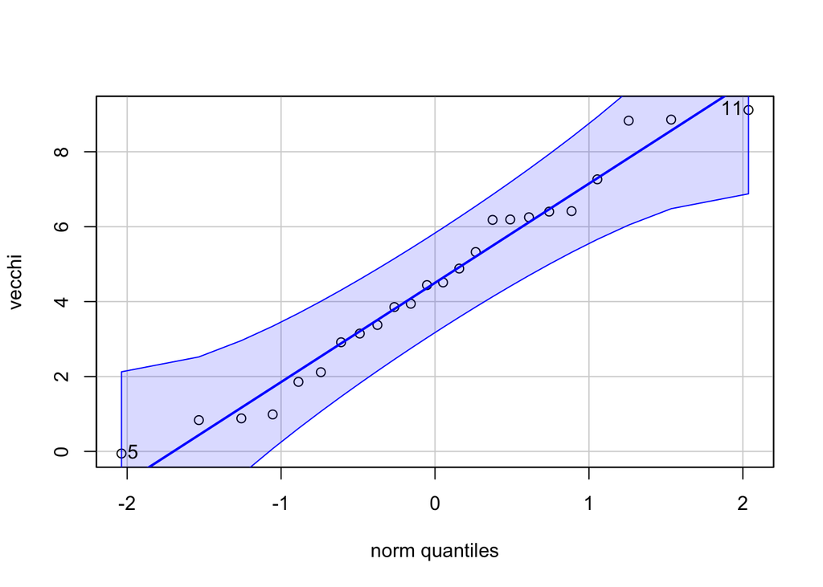

```
## [1] 11  5
```

```r
qqPlot(vecchi)
```

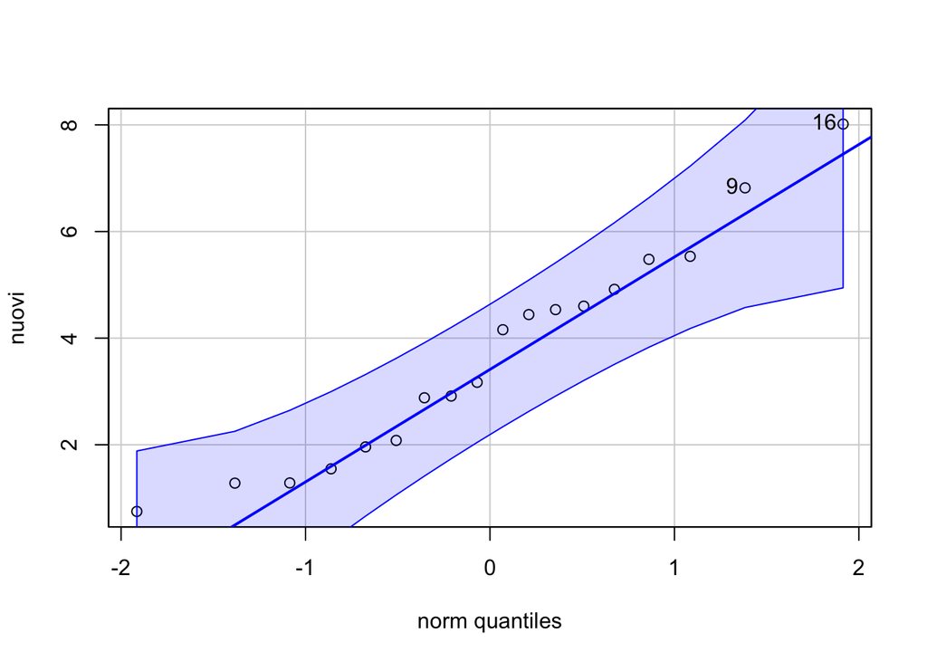

```
## [1] 16  9
```

```r
qqPlot(nuovi)
```

I grafici quantile-quantile sono del tutto soddisfacenti percui riteniamo l’assunzione di normalità soddisfatta.

Risposta al primo quesito:

```r
t.test(vecchi)
```

```
##
##  One Sample t-test
##
## data:  vecchi
## t = 8.3433, df = 23, p-value = 2.07e-08
## alternative hypothesis: true mean is not equal to 0
## 95 percent confidence interval:
##  3.400893 5.643344
## sample estimates:
## mean of x
##  4.522119
```

Il calcolo conferma il risultato ottenuto al punto [1].

Risposta al secondo quesito:

```r
t.test(vecchi, nuovi, alternative = "greater")
```

```
##
##  Welch Two Sample t-test
##
## data:  vecchi and nuovi
## t = 1.1521, df = 39.959, p-value = 0.1281
## alternative hypothesis: true difference in means is greater than 0
## 95 percent confidence interval:
##  -0.3854611        Inf
## sample estimates:
## mean of x mean of y
##  4.522119  3.687002
```

Il calcolo conferma il risultato ottenuto al punto [2].